# Skagit Sockeye Forecast

Casey Ruff, modified original code from Thomas Buehrens

Last Updated 07/23/2025.

# Overview

This script fits log-normal Generalized Additive Models and ARIMA models to salmon run-size data with or without regression covariates. These models are then used to generate one-Year-ahead forecasts. The data used to fit the models is split into “training” and “validation” sets to evaluate performance of the one-Year-ahead forecasts, compare models, and develop weighted “ensemble” forecasts. The code repository used to generate this page and complete analyses can be found here: [**(link)**](https://github.com/tbuehrens/Salmon_Forecast_Example)

# Setup

All analyses require R software [**(link)**](https://cran.r-project.org/) (v3.4.3) for data retrieval, data processing, and summarizing model results. Here we configure R to perform our analysis and generate our outputs

```r
options(width = 100)
knitr::opts_chunk$set(message = FALSE)
set.seed(123)
```

```r
wd_functions<-"functions"
sapply(FUN = source, paste(wd_functions, list.files(wd_functions), sep="/"))
```

Here we will load & install packages we need to use (needs internet connection if packages not already installed)

```r
packages_list<-c("readr"
                 ,"tidyverse"
                 ,"forecast"
                 ,"mgcv"
                 ,"ggplot2"
                 ,"MASS"
                 ,"RColorBrewer"
                 ,"kableExtra"
                 ,"gtools"
                 # ,"ggfortify"
                 ,"lubridate"
                 #,"brms"
                 ,"here"
                 # ,"rnoaa"
                 # ,"ncdf4"
                 # ,"ncdf4.helpers"
                 # ,"raster"
                 # ,"reshape2"
                 # ,"ggfortify"
                 #
                 )
install_or_load_pack(pack = packages_list)

## set data dir
datadir <- here("data")
```

# Load Data

Here we will load and format our data for analysis. First, we will load and format our fish data for analysis. What you load is what you will forecast (so you can forecast run size or escapement)

```r
#====================================
#get Skagit Sockeye data as example
#====================================

dat <- read_csv(file.path(datadir, "baker_sockeye_SAR.csv"))
Yrlist<-data.frame(Year=c(min(dat$Year):(max(dat$Year) + 1)))

dat <- dat%>%
  right_join(Yrlist)

SAR<-dat%>%
  right_join(Yrlist)%>%
  filter(Year >= 2000 & Year<2024)

SAR<-SAR%>%bind_cols(SAR1=data.frame(SAR1=gam(cbind(round(OA1_Recruits),smolts-round(OA1_Recruits))~s(Year,k=(dim(SAR)[1]),m=1,bs="ps"),family=quasibinomial,data=SAR)$fitted))%>%
  bind_cols(SAR2=data.frame(SAR2=c(NA,gam(cbind(round(OA2_Recruits),smolts-round(OA2_Recruits))~s(Year,k=(dim(SAR)[1]-1),m=1,bs="ps"),family=quasibinomial,data=SAR)$fitted)))%>%
  mutate(Year=Year+2,lag1_log_SAR1 = lag(log(SAR1),1),lag1_log_SAR2=log(SAR2))%>%
  dplyr::select(Year=Year,lag1_log_SAR1,lag1_log_SAR2)

#look at our data
print(tail(data.frame(dat)))
```

```
##    Year  smolts runsize_obs Total_Recruits OA1_Recruits OA2_Recruits OA3_Recruits  Total_SAR
## 29 2020  856688       19379       36412.66    1504.4937     27009.56     7898.610 0.04250400
## 30 2021  763622       31436       61830.59     489.8953     57458.52     3882.184 0.08097016
## 31 2022  703330       37428             NA     154.8747     42647.76           NA         NA
## 32 2023 1167453       65512             NA    1294.0612           NA           NA         NA
## 33 2024      NA       47824             NA           NA           NA           NA         NA
## 34 2025      NA          NA             NA           NA           NA           NA         NA
##       OA2_SAR     OA3_SAR
## 29 0.03152788 0.009219938
## 30 0.07524471 0.005083907
## 31 0.06063691          NA
## 32         NA          NA
## 33         NA          NA
## 34         NA          NA
```

```r
print(tail(data.frame(SAR)))
```

```
##    Year lag1_log_SAR1 lag1_log_SAR2
## 19 2020     -9.331668     -4.062503
## 20 2021     -9.412975     -3.969544
## 21 2022     -8.114176     -3.620952
## 22 2023     -6.607696     -3.239448
## 23 2024     -7.173607     -2.724248
## 24 2025     -7.707080     -2.742448
```

```r
#=========================================================
#get smolts
#=========================================================
Smolts<-read_csv(here("data","baker_sockeye_SAR.csv"))%>%
  dplyr::mutate(Year=Year+2,lag2_log_smolts=log(smolts))%>%
  dplyr::select(Year,lag2_log_smolts)
```

The section will (optionally) download from the web (or load from the data folder) NOAA Ocean Indicator data, NOAA Ocean Buoy SST data, and NOAA smoothed modeled SST data (ERSST_V5), flow data, PIT tag data, or any other covariate data not included with the fish data that could assist in forecasting.

```r
#=========================================================
#get NPGO data
#=========================================================
NPGO<-read_table("https://www.o3d.org/npgo/data/NPGO.txt",skip=29,col_names=F,comment="#")%>%
  filter(!is.na(X2))%>%
  dplyr::rename(Year=X1,Month=X2,NPGO=X3)%>%
  mutate(Year=as.numeric(Year))%>%
  group_by(Year)%>%
  add_tally()%>%
  filter(Month == 2)%>%
  #filter(!Month>6)%>% #use only spring (Jan-June) NPGO
  #filter(!n < 12)%>% #use only complete Years
  group_by(Year)%>%
  dplyr::summarise(NPGO=mean(NPGO))%>%
  mutate(Year=Year+1, lag1_NPGO = NPGO,lag2_NPGO = lag(NPGO,1))%>%
  dplyr::select(Year=Year,lag1_NPGO,lag2_NPGO)

#=========================================================
#get NOAA indicator data, wrangle into usable format, plot
#=========================================================
#indicators<-read_csv("https://media.fisheries.noaa.gov/2021-04/Stoplight%20csv.csv?null",skip=1)%>%
indicators<-read_csv("data/Stoplight csv.csv",skip=1)%>%
  filter(!is.na(`Ecosystem Indicators`))%>%
  pivot_longer(names_to = "Year",
                cols=c(starts_with("1"),starts_with("2")),
                values_to = "value")%>%
  pivot_wider(names_from=`Ecosystem Indicators`,values_from=value)%>%
  mutate(Year=as.numeric(Year))

# plotdat<-indicators%>%pivot_longer(names_to = "indicators", cols = colnames(indicators)[colnames(indicators)!="Year"])
# ggplot(plotdat,aes(x=value,color=indicators))+
#   geom_density()+
#   facet_wrap(~indicators,scales="free")+
#   theme(legend.position = "none")

#==============================================================
# get NOAA sst data directly from Buoys (takes a while to run)
#==============================================================
# buoylist<-c(46229, 46211, 46041, 46029, 46050, 46097, 46098)
# Years<-c(1980:2021)
# buoy_stations()%>%filter(lat > 44 & lat < 52 & lon > -130 & lon < -120)
# buoydat<-getbuoydata(buoylist = buoylist,Years=Years)
# write.csv(dat,"SST.csv",row.names = F)

#===================
#Plot Buoy SST data
#====================
# buoydat<-buoydat%>%
#   filter(!is.na(buoyid) & !is.na(meanSST))%>%
#   group_by(buoyid,month)%>%
#   mutate(gmeanSST=mean(meanSST),resid=meanSST-gmeanSST)
#
#
# ggplot(buoydat,aes(x=month,y=resid,group=factor(buoyid),color=factor(buoyid)))+
#   geom_hline(yintercept=0,linetype="dashed")+
#   scale_color_brewer(palette = "Spectral")+
#   geom_line()+
# facet_wrap(~factor(Year))


#===========================================================================================================
#Get ERSST data: get_ersst_v5_data takes A LONG TIME (1 hr) vs. get_ersst_v5_data_V2 which is much quicker!
#===========================================================================================================
#dat<-get_ersst_v5_data(Years=Years,data.dir=getwd(),latrange=c(44,52),lonrange=c(-130,-120))
# data.dir<-"C:/Users/buehrtwb/OneDrive - Washington State Executive Branch Agencies/Documents"
# sstdat<-get_ersst_v5_data_V2(Years=c(1980:2021),data.dir=data.dir ,ncfilename="SSTv5.nc",latrange=c(44,50),lonrange=c(-125,-120))
#
# sstdat<-sstdat%>%
#   mutate(sstdiff=c(NA,diff(resid)))
#
# #================
# #Plot ERSST data
# #================
# ggplot(sstdat,aes(x=factor(month),y=meanSST,group=Year))+
#   geom_hline(yintercept=0,linetype="dashed")+
#   scale_color_brewer(palette = "Spectral")+
#   geom_line()+
#   facet_wrap(~factor(Year))
#
# ggplot(sstdat,aes(x=factor(month),y=resid,group=Year))+
#   geom_hline(yintercept=0,linetype="dashed")+
#   scale_color_brewer(palette = "Spectral")+
#   geom_line()+
#   facet_wrap(~factor(Year))
#
# ggplot(sstdat,aes(x=factor(month),y=sstdiff,group=Year))+
#   geom_hline(yintercept=0,linetype="dashed")+
#   scale_color_brewer(palette = "Spectral")+
#   geom_line()+
#   facet_wrap(~factor(Year))
#
# ssta<-sstdat%>%
#   dplyr::select(Year,month,resid)%>%
#   mutate(month = paste0("m_",month))%>%
#   rename(Year = Year)%>%
#   pivot_wider(names_from = month,values_from = resid)
#
# pcdat<-ssta%>%
#   ungroup()%>%
#   filter(Year<2021)%>%
#   column_to_rownames(var="Year")
# mod<-prcomp(pcdat
#             )
# autoplot(mod,data=ssta%>%filter(Year<2021)%>%column_to_rownames(var="Year"),
#          x=1,
#          y=3,
#          label = TRUE,
#          label.size = 3,
#          shape=F)
```

If we loaded/downloaded covariate data (other than fish abundance) for use in forecasting, in this section we will merge it with our fish data to produce a final dataframe. Note the format below; the rest of the functions and sections rely on your data being formatted this way,

```r
dat <- dat%>%
  left_join(SAR)%>%
  left_join(Smolts)%>%
  left_join(NPGO)%>%
  dplyr::select(Year=Year,runsize_obs,lag1_log_SAR2,lag2_NPGO,lag2_log_smolts)

# dat<-dat%>%
#   #left_join(PIT)%>%
#   left_join(NPGO)%>%
#   #left_join(indicators)%>%
#   #left_join(ssta)%>%
#   mutate(
#     # l1aprssta= lag(scale(m_04)),
#     # l1mayssta= lag(scale(m_05)),
#     # l1junssta= lag(scale(m_06)),
#     # l1julssta= lag(scale(m_07)),
#     # l1augssta= lag(scale(m_08)),
#     # l1sepssta= lag(scale(m_09)),
#     # l1octssta= lag(scale(m_10)),
#     # l1novssta= lag(scale(m_11)),
#     # l1decssta= lag(scale(m_12)),
#     # l1FallSST= (lag(scale(m_10)) + lag(scale(m_11)) + lag(scale(m_12)))/3
#     # PC1 = lag(mod$x[,1]),
#     # PC2 = lag(mod$x[,2]),
#     # PC3 = lag(mod$x[,3]),
#     # lag1_summerPDO = lag(scale(`PDO\n(Sum May-Sept)`)),
#     # lag1_springONI = lag(scale(`ONI\n(Average Jan-June)`)),
#     # lag1_summerdeepSST = lag(scale(`Deep temperature\n(°C; May-Sept)`)),
#     # lag1_summerdeepSalinity = lag(scale(`Deep salinity\n(May-Sept)`)),
#     # lag1_copepodrich = lag(scale(`Deep salinity\n(May-Sept)`)),
#     # lag1_icthy = lag(scale(`Nearshore Ichthyoplankton\nLog(mg C 1,000 m-3; Jan-Mar)`)),
#     # lag1_cpueCO = lag(scale(log(`Steelhead salmon juvenile\ncatches (no. km-1; June)`))),
#     # lag1_phystrans = lag (scale(`Physical Spring Trans.\nUI based (day of Year)`)),
#     # lag1_Ncope = lag(scale(`N. copepod biomass anom.\n(mg C m-3; May-Sept)`)),
#     # lag1_summerSST=lag(scale(`Upper 20 m T\n(°C; May-Sept)`)),
#     lag2_NPGO = lag(NPGO,2),
#     #lag3_NPGO = lag(NPGO,3),
#     lag2_smolts = log(lag(smolts,2)),
#     #lag3_smolts = lag(smolts,3)
#     )



#select variables to include in analysis and subset data

#vars<-c("lag1_log_SAR2","lag2_NPGO")

vars<-c("lag1_log_SAR2","lag2_log_smolts","lag2_NPGO") #what regression variables will we use?
dat<-data.frame(dat)%>%
  dplyr::select(Year,runsize_obs,all_of(vars))%>%
  filter(
    across(
      .cols = all_of(vars),
      .fns = ~ !is.na(.x)
    )
  )

#sockeye_cov <- data.frame(dat[,c(1,5:6)])
# pcdat<-sockeye_cov%>%
#   ungroup()%>%
#   column_to_rownames(var="Year")
# mod<-prcomp(pcdat)
# dat <- data.frame(dat,PC1_smolts = mod$x[,1],PC2_smolts = mod$x[,2])

#look at our data
print(data.frame(dat))
```

```
##    Year runsize_obs lag1_log_SAR2 lag2_log_smolts   lag2_NPGO
## 1  2003       20977     -2.135231        12.18052  2.95604680
## 2  2004       11309     -2.399830        11.91492  2.17735680
## 3  2005        3587     -2.908781        11.16798  0.99256558
## 4  2006        9828     -3.140837        12.04837  0.66722957
## 5  2007        3720     -3.245224        11.67064 -1.59937210
## 6  2008        5763     -3.686608        12.57523 -0.96233149
## 7  2009        6727     -3.905275        11.97202 -0.02327933
## 8  2010       22778     -3.478871        12.44116  1.26499550
## 9  2011       37057     -2.575693        12.74531  0.83058122
## 10 2012       47971     -2.314713        12.98674  1.83517420
## 11 2013       17804     -2.551069        12.25252  0.28653615
## 12 2014       27143     -2.943456        13.06034  0.71751176
## 13 2015       51074     -2.951157        13.53885  1.11054790
## 14 2016       42910     -2.857276        13.75351 -0.23148509
## 15 2017       33359     -3.242468        13.45992 -1.31676700
## 16 2018       30996     -3.377902        13.57681  0.26207514
## 17 2019       22445     -3.498840        13.90617 -0.60273850
## 18 2020       19379     -4.062503        13.65304 -2.25091610
## 19 2021       31436     -3.969544        13.54109 -2.60500710
## 20 2022       37428     -3.620952        13.66083 -2.36906880
## 21 2023       65512     -3.239448        13.54583 -1.13124630
## 22 2024       47824     -2.724248        13.46358 -2.09359350
## 23 2025          NA     -2.742448        13.97034 -1.99010790
```

# Set Parameters

Here we specify parameters for our forecast training and evaluation: how many Years of training data to include in the training set (validation is the rest), how many Years forward to forecast (typically 1), and make some selections regarding which metric to use to evaluate forecast odel performance.

```r
#set model fitting and evaluation params
TY <- dim(dat)[1]-12 #training Years (Years of training data)
FY <- 1 #forecast Years (Years forward to forecast)
k = 1 #this is the model-averaging weighting exponent--default is 1, larger numbers will tend to more heavily weight "best" models over lower ranked models
stack_metric = "MSA" #this is the performance measure that will be optimized to find the best stack weights
```

# Fit Forecast Models

Here we fit ARIMA and GAM forecasts

```r
#==========
#ARIMA models
#==========
ARIMA100<-tsCV2(y=log(dat$runsize_obs[-dim(dat)[1]]),
            Year=dat$Year,
            xreg=NULL,
            h=FY,
            min=TY,
            type="ARIMA",
            order=c(1,0,0)
)

ARIMA100_withcov_NPGO_smolts_SAR1<-tsCV2(y=log(dat$runsize_obs[-dim(dat)[1]]),
            Year=dat$Year,
            xreg=dat%>%dplyr::select("lag1_log_SAR2","lag2_log_smolts","lag2_NPGO")%>%as.matrix(),
            h=FY,
            min=TY,
            type="ARIMA",
            order=c(1,0,0)
      )

ARIMA100_withcov_NPGO<-tsCV2(y=log(dat$runsize_obs[-dim(dat)[1]]),
            Year=dat$Year,
            xreg=dat%>%dplyr::select("lag2_NPGO")%>%as.matrix(),
            h=FY,
            min=TY,
            type="ARIMA",
            order=c(1,0,0)
      )

ARIMA100_withcov_smolts<-tsCV2(y=log(dat$runsize_obs[-dim(dat)[1]]),
            Year=dat$Year,
            xreg=dat%>%dplyr::select("lag2_log_smolts")%>%as.matrix(),
            h=FY,
            min=TY,
            type="ARIMA",
            order=c(1,0,0)
      )

ARIMA100_withcov_SAR1<-tsCV2(y=log(dat$runsize_obs[-dim(dat)[1]]),
            Year=dat$Year,
            xreg=dat%>%dplyr::select("lag1_log_SAR2")%>%as.matrix(),
            h=FY,
            min=TY,
            type="ARIMA",
            order=c(1,0,0)
      )

ARIMA111_withcov_NPGO_smolts_SAR1<-tsCV2(y=log(dat$runsize_obs[-dim(dat)[1]]),
            Year=dat$Year,
            xreg=dat%>%dplyr::select("lag1_log_SAR2","lag2_log_smolts","lag2_NPGO")%>%as.matrix(),
            h=FY,
            min=TY,
            type="ARIMA",
            order=c(1,1,1)
)

ARIMA111_withcov_NPGO<-tsCV2(y=log(dat$runsize_obs[-dim(dat)[1]]),
            Year=dat$Year,
            xreg=dat%>%dplyr::select("lag2_NPGO")%>%as.matrix(),
            h=FY,
            min=TY,
            type="ARIMA",
            order=c(1,1,1)
)


ARIMA111_withcov_smolts<-tsCV2(y=log(dat$runsize_obs[-dim(dat)[1]]),
            Year=dat$Year,
            xreg=dat%>%dplyr::select("lag2_log_smolts")%>%as.matrix(),
            h=FY,
            min=TY,
            type="ARIMA",
            order=c(1,1,1)
)


ARIMA111_withcov_SAR1<-tsCV2(y=log(dat$runsize_obs[-dim(dat)[1]]),
            Year=dat$Year,
            xreg=dat%>%dplyr::select("lag1_log_SAR2")%>%as.matrix(),
            h=FY,
            min=TY,
            type="ARIMA",
            order=c(1,1,1)
)

ARIMA010_withcov_NPGO_smolts_SAR1<-tsCV2(y=log(dat$runsize_obs[-dim(dat)[1]]),
            Year=dat$Year,
            xreg=dat%>%dplyr::select("lag1_log_SAR2","lag2_log_smolts","lag2_NPGO")%>%as.matrix(),
            h=FY,
            min=TY,
            type="ARIMA",
            order=c(0,1,0)
)

ARIMA010_withcov_NPGO<-tsCV2(y=log(dat$runsize_obs[-dim(dat)[1]]),
            Year=dat$Year,
            xreg=dat%>%dplyr::select("lag2_NPGO")%>%as.matrix(),
            h=FY,
            min=TY,
            type="ARIMA",
            order=c(0,1,0)
)

ARIMA010_withcov_smolts<-tsCV2(y=log(dat$runsize_obs[-dim(dat)[1]]),
            Year=dat$Year,
            xreg=dat%>%dplyr::select("lag2_log_smolts")%>%as.matrix(),
            h=FY,
            min=TY,
            type="ARIMA",
            order=c(0,1,0)
)

ARIMA010_withcov_SAR1<-tsCV2(y=log(dat$runsize_obs[-dim(dat)[1]]),
            Year=dat$Year,
            xreg=dat%>%dplyr::select("lag1_log_SAR2")%>%as.matrix(),
            h=FY,
            min=TY,
            type="ARIMA",
            order=c(0,1,0)
)

ARIMA010<-tsCV2(y=log(dat$runsize_obs[-dim(dat)[1]]),
            Year=dat$Year,
            xreg=NULL,
            h=FY,
            min=TY,
            type="ARIMA",
            order=c(0,1,0)
)
# ARIMA111<-tsCV2(y=log(dat$runsize_obs[-dim(dat)[1]]),
#             Year=dat$Year,
#             xreg=NULL,
#             h=FY,
#             min=TY,
#             type="ARIMA",
#             order=c(1,1,1)
# )
ARIMA101_withcov_NPGO_smolts_SAR1<-tsCV2(y=log(dat$runsize_obs[-dim(dat)[1]]),
            Year=dat$Year,
            xreg=dat%>%dplyr::select("lag1_log_SAR2","lag2_log_smolts","lag2_NPGO")%>%as.matrix(),
            h=FY,
            min=TY,
            type="ARIMA",
            order=c(1,0,1)
)

ARIMA101_withcov_NPGO<-tsCV2(y=log(dat$runsize_obs[-dim(dat)[1]]),
            Year=dat$Year,
            xreg=dat%>%dplyr::select("lag2_NPGO")%>%as.matrix(),
            h=FY,
            min=TY,
            type="ARIMA",
            order=c(1,0,1)
)

ARIMA101_withcov_smolts<-tsCV2(y=log(dat$runsize_obs[-dim(dat)[1]]),
            Year=dat$Year,
            xreg=dat%>%dplyr::select("lag2_log_smolts")%>%as.matrix(),
            h=FY,
            min=TY,
            type="ARIMA",
            order=c(1,0,1)
)

ARIMA101_withcov_SAR1<-tsCV2(y=log(dat$runsize_obs[-dim(dat)[1]]),
            Year=dat$Year,
            xreg=dat%>%dplyr::select("lag1_log_SAR2")%>%as.matrix(),
            h=FY,
            min=TY,
            type="ARIMA",
            order=c(1,0,1)
)



ARIMA101<-tsCV2(y=log(dat$runsize_obs[-dim(dat)[1]]),
            Year=dat$Year,
            xreg=NULL,
            h=FY,
            min=TY,
            type="ARIMA",
            order=c(1,0,1)
)
ARIMA001_withcov_NPGO_smolts_SAR1<-tsCV2(y=log(dat$runsize_obs[-dim(dat)[1]]),
            Year=dat$Year,
            xreg=dat%>%dplyr::select("lag1_log_SAR2","lag2_log_smolts","lag2_NPGO")%>%as.matrix(),
            h=FY,
            min=TY,
            type="ARIMA",
            order=c(0,0,1)
)

ARIMA001_withcov_NPGO<-tsCV2(y=log(dat$runsize_obs[-dim(dat)[1]]),
            Year=dat$Year,
            xreg=dat%>%dplyr::select("lag2_NPGO")%>%as.matrix(),
            h=FY,
            min=TY,
            type="ARIMA",
            order=c(0,0,1)
)

ARIMA001_withcov_smolts<-tsCV2(y=log(dat$runsize_obs[-dim(dat)[1]]),
            Year=dat$Year,
            xreg=dat%>%dplyr::select("lag2_log_smolts")%>%as.matrix(),
            h=FY,
            min=TY,
            type="ARIMA",
            order=c(0,0,1)
)

ARIMA001_withcov_SAR1<-tsCV2(y=log(dat$runsize_obs[-dim(dat)[1]]),
            Year=dat$Year,
            xreg=dat%>%dplyr::select("lag1_log_SAR2")%>%as.matrix(),
            h=FY,
            min=TY,
            type="ARIMA",
            order=c(0,0,1)
)


ARIMA001<-tsCV2(y=log(dat$runsize_obs[-dim(dat)[1]]),
            Year=dat$Year,
            xreg=NULL,
            h=FY,
            min=TY,
            type="ARIMA",
            order=c(0,0,1)
)
#==========
#GAM models
#==========
gam<-tsCV2(y=log(dat$runsize_obs[-dim(dat)[1]]),
            Year=dat$Year,
            xreg=NULL,
            h=FY,
            min=TY,
            type="gam",
            m=1,
            knots=dim(dat)[1]-1
)
# LFO10<-tsCV2(y=log(dat$runsize_obs[-dim(dat)[1]]),
#             Year=dat$Year,
#             xreg=dat%>%dplyr::select(all_of(vars))%>%as.matrix(),
#             h=FY,
#             min=TY,
#             type="gam"
#             m=1,
#             knots=dim(dat)[1]-1
# )
#================================
#BRMS models with Horseshoe Prior
#================================
# gp_horseshoe<-fc3(
#   Year=dat$Year,
#   TY=TY
#   ,vars=vars
#   ,dat=dat
#   ,formula = as.formula(paste0("log(runsize_obs) ~ gp(Year) + ",paste(vars,collapse = "+")))
#   ,prior = set_prior(horseshoe(df = 1, par_ratio = 0.5), class="b")
# )
# LFO12<-fc3(
#   Year=dat$Year,
#   TY=TY
#   ,vars=vars
#   ,dat=dat
#   ,formula = as.formula(paste0("log(runsize_obs) ~ arma(p = 1, q = 1, cov=TRUE) + ",paste(vars,collapse = "+")))
#   ,prior = set_prior(horseshoe(df = 1, par_ratio = 0.5), class="b")
# )
```

# Summarize Forecasts

```r
#===================
#Summarize Forecasts
#===================
forecasts<-summarize_forecasts(
   c("ARIMA100",
    "ARIMA100_withcov_NPGO_smolts_SAR1",
    "ARIMA100_withcov_NPGO",
    "ARIMA100_withcov_smolts",
    "ARIMA100_withcov_SAR1",
    "ARIMA111_withcov_NPGO_smolts_SAR1",
    "ARIMA111_withcov_NPGO",
    "ARIMA111_withcov_smolts",
    "ARIMA111_withcov_SAR1",
    "ARIMA010_withcov_NPGO_smolts_SAR1",
    "ARIMA010_withcov_NPGO",
    "ARIMA010_withcov_smolts",
    "ARIMA010_withcov_SAR1",
    "ARIMA010",
    #,"ARIMA111",
    "ARIMA101_withcov_NPGO_smolts_SAR1",
    "ARIMA101_withcov_NPGO",
    "ARIMA101_withcov_smolts",
    "ARIMA101_withcov_SAR1",
    "ARIMA101",
    "ARIMA001_withcov_NPGO_smolts_SAR1",
    "ARIMA001_withcov_NPGO",
    "ARIMA001_withcov_smolts",
    "ARIMA001_withcov_SAR1",
    "ARIMA001",
    "gam"
    # LFO10
    #,"gp_horseshoe"
    #LFO12
    )
)
#========================================
#Table of forecast results for final Year
#========================================
forecasts%>%
  group_by(Model)%>%
  filter(Year==max(Year,na.rm = T))%>%
  kbl(caption = "Table 1. Forecasts for final Year of data.",digits =0)%>%
  kable_classic(full_width = F, html_font = "Cambria")
```

Table 1. Forecasts for final Year of data.

| Model | Year | Estimate | L95 | U95 |
| --- | --- | --- | --- | --- |
| ARIMA100 | 2025 | 38473 | 11885 | 124545 |
| ARIMA100_withcov_NPGO_smolts_SAR1 | 2025 | 65353 | 33610 | 127076 |
| ARIMA100_withcov_NPGO | 2025 | 43622 | 16495 | 115360 |
| ARIMA100_withcov_smolts | 2025 | 69218 | 30920 | 154952 |
| ARIMA100_withcov_SAR1 | 2025 | 40680 | 13133 | 126008 |
| ARIMA111_withcov_NPGO_smolts_SAR1 | 2025 | 65375 | 31957 | 133739 |
| ARIMA111_withcov_NPGO | 2025 | 49737 | 18441 | 134148 |
| ARIMA111_withcov_smolts | 2025 | 62020 | 26229 | 146650 |
| ARIMA111_withcov_SAR1 | 2025 | 60811 | 19594 | 188730 |
| ARIMA010_withcov_NPGO_smolts_SAR1 | 2025 | 69764 | 35217 | 138201 |
| ARIMA010_withcov_NPGO | 2025 | 49688 | 19377 | 127416 |
| ARIMA010_withcov_smolts | 2025 | 77222 | 33010 | 180651 |
| ARIMA010_withcov_SAR1 | 2025 | 47284 | 14862 | 150434 |
| ARIMA010 | 2025 | 47824 | 14128 | 161889 |
| ARIMA101_withcov_NPGO_smolts_SAR1 | 2025 | 54483 | 28424 | 104431 |
| ARIMA101_withcov_NPGO | 2025 | 43272 | 15955 | 117360 |
| ARIMA101_withcov_smolts | 2025 | 51558 | 24208 | 109808 |
| ARIMA101_withcov_SAR1 | 2025 | 48081 | 15486 | 149283 |
| ARIMA101 | 2025 | 38758 | 11615 | 129337 |
| ARIMA001_withcov_NPGO_smolts_SAR1 | 2025 | 54567 | 28991 | 102704 |
| ARIMA001_withcov_NPGO | 2025 | 22612 | 5605 | 91227 |
| ARIMA001_withcov_smolts | 2025 | 44944 | 21193 | 95317 |
| ARIMA001_withcov_SAR1 | 2025 | 26019 | 6441 | 105107 |
| ARIMA001 | 2025 | 24757 | 6242 | 98188 |
| gam | 2025 | 50025 | 28340 | 88303 |

# Evaluate Forecasts

Here we will evaluate forecasts using Mean Absolute Percent Error (MAPE), Root Mean Squared Error (RMSE), and Median Symmetric Accuracy (MSA). RMSE and MAPE tend to more heavily penalize over-forecasts relative to under-forecasts for abundance (because errors are right-skewed), whereas MSA is specifically tailored for right tailed distributions. We will also calculated model weights

```r
forecast_skill<-evaluate_forecasts(forecasts=forecasts,observations=dat)

forecasts[which(forecasts$Model %in% forecast_skill$Model[1:10]),]
```

```
## # A tibble: 120 x 5
##    Model     Year Estimate   L95     U95
##    <chr>    <dbl>    <dbl> <dbl>   <dbl>
##  1 ARIMA100  2014   15475. 3420.  70023.
##  2 ARIMA100  2015   20570. 4740.  89264.
##  3 ARIMA100  2016   33785. 7679. 148634.
##  4 ARIMA100  2017   31620. 7639. 130881.
##  5 ARIMA100  2018   27051. 6913. 105853.
##  6 ARIMA100  2019   26098. 7003.  97260.
##  7 ARIMA100  2020   20874. 5842.  74586.
##  8 ARIMA100  2021   18878. 5498.  64812.
##  9 ARIMA100  2022   26649. 7871.  90231.
## 10 ARIMA100  2023   30663. 9292. 101185.
## # ... with 110 more rows
```

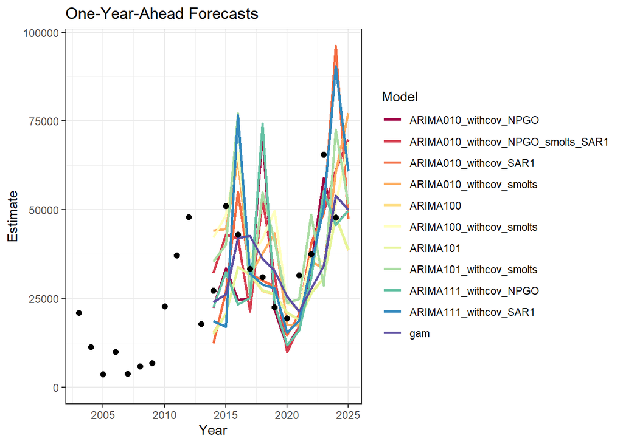

```r
#===========================
#Plot of final Year forecast
#===========================
ggplot(data=forecasts[which(forecasts$Model %in% forecast_skill$Model[1:11]),],aes(x=Year,y=Estimate,color=Model))+
  labs(title="One-Year-Ahead Forecasts")+
  geom_line(size=1)+
  scale_color_brewer(palette="Spectral")+
  geom_point(data=dat,mapping=aes(x=Year,y=runsize_obs),size=2,color="black")+
  ylim(0,NA)+
  theme_bw()
```

```r
#=======================
#Table of Forecast Skill
#=======================
forecast_skill%>%
  kbl(caption = "Table 2.Forecast Performance based on full set of one-Year-ahead forecasts.",digits =3)%>%
  kable_classic(full_width = F, html_font = "Cambria")
```

Table 2.Forecast Performance based on full set of one-Year-ahead forecasts.

| Model | RMSE | MAPE | MSA |
| --- | --- | --- | --- |
| ARIMA010_withcov_smolts | 15526.49 | 34.511 | 26.778 |
| ARIMA100 | 15586.88 | 26.225 | 27.009 |
| ARIMA101 | 15640.46 | 26.435 | 27.442 |
| ARIMA111_withcov_SAR1 | 20518.45 | 35.724 | 29.370 |
| gam | 13844.29 | 27.563 | 31.321 |
| ARIMA010_withcov_NPGO_smolts_SAR1 | 11900.55 | 30.956 | 32.681 |
| ARIMA111_withcov_NPGO | 16908.46 | 35.824 | 32.698 |
| ARIMA010_withcov_SAR1 | 18448.66 | 32.359 | 32.914 |
| ARIMA101_withcov_smolts | 20223.56 | 45.230 | 33.112 |
| ARIMA010_withcov_NPGO | 15652.60 | 33.049 | 33.656 |
| ARIMA100_withcov_smolts | 15624.87 | 35.257 | 34.710 |
| ARIMA100_withcov_NPGO_smolts_SAR1 | 12664.89 | 29.810 | 36.516 |
| ARIMA010 | 14105.89 | 29.516 | 36.986 |
| ARIMA001_withcov_smolts | 18023.63 | 39.860 | 39.207 |
| ARIMA001_withcov_NPGO_smolts_SAR1 | 15124.89 | 35.186 | 41.645 |
| ARIMA101_withcov_SAR1 | 17101.41 | 35.144 | 42.805 |
| ARIMA100_withcov_SAR1 | 17072.32 | 35.767 | 46.638 |
| ARIMA101_withcov_NPGO_smolts_SAR1 | 15470.43 | 35.763 | 47.710 |
| ARIMA111_withcov_NPGO_smolts_SAR1 | 13319.32 | 34.297 | 53.585 |
| ARIMA111_withcov_smolts | 22220.94 | 45.695 | 53.852 |
| ARIMA101_withcov_NPGO | 16222.75 | 40.352 | 57.094 |
| ARIMA100_withcov_NPGO | 15934.74 | 39.172 | 57.338 |
| ARIMA001 | 19991.14 | 39.036 | 59.816 |
| ARIMA001_withcov_SAR1 | 21275.02 | 48.319 | 91.147 |
| ARIMA001_withcov_NPGO | 22586.71 | 52.281 | 102.945 |

# Ensembles & Ensemble Performance

Calculate leave-forward-out performance Year by Year in order to develop weighted ensembles (with recalculated weights each Year). Then evaluate performance of these one-Year-ahead ensembles and compare with original models. Note that one fewer Years of leave-forward-out forecasts is evaluated since an ensemble using previous Years’ forecast skill can only be created for the second through last Years of leave-forward-out forecasts.

```r
ensemble_results<-evaluate_forecasts_with_ensembles(forecasts = forecasts, observations = dat)
#=================================
#Table of final Year model weights
#=================================
ensemble_results$final_model_weights%>%
  dplyr::select(Model, RMSE_weight, MAPE_weight, MSA_weight, Stacking_weight)%>%
  kbl(caption = "Table 3. Final Year Model Weights based on full dataset of one-Year-ahead performance.",digits =3)%>%
  kable_classic(full_width = F, html_font = "Cambria")
```

Table 3. Final Year Model Weights based on full dataset of one-Year-ahead performance.

| Model | RMSE_weight | MAPE_weight | MSA_weight | Stacking_weight |
| --- | --- | --- | --- | --- |
| ARIMA010_withcov_smolts | 0.042 | 0.041 | 0.059 | 0.341 |
| ARIMA100 | 0.042 | 0.053 | 0.058 | 0.000 |
| ARIMA101 | 0.042 | 0.053 | 0.057 | 0.655 |
| ARIMA111_withcov_SAR1 | 0.032 | 0.039 | 0.054 | 0.000 |
| gam | 0.047 | 0.051 | 0.050 | 0.000 |
| ARIMA010_withcov_NPGO_smolts_SAR1 | 0.055 | 0.045 | 0.048 | 0.000 |
| ARIMA111_withcov_NPGO | 0.039 | 0.039 | 0.048 | 0.000 |
| ARIMA010_withcov_SAR1 | 0.035 | 0.043 | 0.048 | 0.000 |
| ARIMA101_withcov_smolts | 0.032 | 0.031 | 0.047 | 0.000 |
| ARIMA010_withcov_NPGO | 0.042 | 0.042 | 0.047 | 0.000 |
| ARIMA100_withcov_smolts | 0.042 | 0.040 | 0.045 | 0.000 |
| ARIMA100_withcov_NPGO_smolts_SAR1 | 0.052 | 0.047 | 0.043 | 0.000 |
| ARIMA010 | 0.046 | 0.048 | 0.042 | 0.000 |
| ARIMA001_withcov_smolts | 0.036 | 0.035 | 0.040 | 0.000 |
| ARIMA001_withcov_NPGO_smolts_SAR1 | 0.043 | 0.040 | 0.038 | 0.000 |
| ARIMA101_withcov_SAR1 | 0.038 | 0.040 | 0.037 | 0.000 |
| ARIMA100_withcov_SAR1 | 0.038 | 0.039 | 0.034 | 0.000 |
| ARIMA101_withcov_NPGO_smolts_SAR1 | 0.042 | 0.039 | 0.033 | 0.000 |
| ARIMA111_withcov_NPGO_smolts_SAR1 | 0.049 | 0.041 | 0.029 | 0.000 |
| ARIMA111_withcov_smolts | 0.029 | 0.031 | 0.029 | 0.000 |
| ARIMA101_withcov_NPGO | 0.040 | 0.035 | 0.028 | 0.000 |
| ARIMA100_withcov_NPGO | 0.041 | 0.036 | 0.027 | 0.000 |
| ARIMA001 | 0.033 | 0.036 | 0.026 | 0.000 |
| ARIMA001_withcov_SAR1 | 0.031 | 0.029 | 0.017 | 0.000 |
| ARIMA001_withcov_NPGO | 0.029 | 0.027 | 0.015 | 0.005 |

```r
#=======================================
#Table of final Year ensemable forecasts
#=======================================
ensemble_results$ensembles%>%
  group_by(Model)%>%
  filter(Year==max(Year,na.rm=T))%>%
  kbl(caption = "Table 4. Ensemble forecasts one Year ahead of final Year of data.",digits =0)%>%
  kable_classic(full_width = F, html_font = "Cambria")
```

Table 4. Ensemble forecasts one Year ahead of final Year of data.

| Year | Model | Estimate | L95 | U95 |
| --- | --- | --- | --- | --- |
| 2025 | MSA_weighted | 51848 | 21398 | 131817 |
| 2025 | RMSE_weighted | 51046 | 21363 | 128423 |
| 2025 | MAPE_weighted | 50441 | 20785 | 129067 |
| 2025 | Stack_weighted | 51781 | 18873 | 146626 |

```r
#=============================
#calc performance of ensembles
#=============================
ensemble_results$forecast_skill%>%
  kbl(caption = "Table 5. One-Year ahead performance of model & model ensemble forecasts. Ensemble weights recalculated annually using weights based on one-head performance up to to and including the Year prior to the forecast Year. Year one of one-Year ahead fits not included since an ensemble cannot be computed for this Year.",digits =3)%>%
  kable_classic(full_width = F, html_font = "Cambria")
```

Table 5. One-Year ahead performance of model & model ensemble forecasts. Ensemble weights recalculated annually using weights based on one-head performance up to to and including the Year prior to the forecast Year. Year one of one-Year ahead fits not included since an ensemble cannot be computed for this Year.

| Model | RMSE | MAPE | MSA |
| --- | --- | --- | --- |
| Stack_weighted | 12163.87 | 18.375 | 9.913 |
| ARIMA100 | 15925.83 | 24.548 | 21.524 |
| ARIMA101 | 15945.93 | 24.595 | 22.128 |
| ARIMA010_withcov_smolts | 15371.92 | 31.701 | 24.021 |
| MAPE_weighted | 12305.81 | 24.979 | 27.292 |
| ARIMA111_withcov_SAR1 | 21351.40 | 36.165 | 28.020 |
| MSA_weighted | 12212.17 | 25.315 | 28.222 |
| ARIMA100_withcov_smolts | 15677.37 | 33.224 | 28.440 |
| RMSE_weighted | 12236.08 | 25.472 | 29.578 |
| ARIMA010_withcov_SAR1 | 18772.74 | 30.133 | 30.431 |
| ARIMA010 | 14496.62 | 29.027 | 32.743 |
| gam | 14484.40 | 29.135 | 33.095 |
| ARIMA010_withcov_NPGO_smolts_SAR1 | 12380.17 | 32.204 | 36.515 |
| ARIMA101_withcov_SAR1 | 17381.50 | 33.503 | 38.922 |
| ARIMA001_withcov_smolts | 18748.04 | 41.028 | 40.658 |
| ARIMA101_withcov_smolts | 21050.66 | 46.723 | 42.069 |
| ARIMA010_withcov_NPGO | 16346.76 | 34.592 | 42.770 |
| ARIMA001_withcov_NPGO_smolts_SAR1 | 15788.38 | 36.912 | 44.294 |
| ARIMA111_withcov_NPGO | 17671.32 | 37.674 | 44.627 |
| ARIMA100_withcov_NPGO_smolts_SAR1 | 13212.88 | 31.202 | 45.593 |
| ARIMA100_withcov_SAR1 | 17281.37 | 33.883 | 46.626 |
| ARIMA101_withcov_NPGO_smolts_SAR1 | 16144.24 | 37.449 | 51.261 |
| ARIMA111_withcov_NPGO_smolts_SAR1 | 13825.93 | 35.400 | 53.639 |
| ARIMA111_withcov_smolts | 23080.76 | 46.503 | 56.178 |
| ARIMA001 | 20416.97 | 37.382 | 59.474 |
| ARIMA100_withcov_NPGO | 16470.29 | 39.786 | 69.405 |
| ARIMA101_withcov_NPGO | 16747.50 | 40.889 | 69.907 |
| ARIMA001_withcov_SAR1 | 21761.03 | 47.402 | 90.462 |
| ARIMA001_withcov_NPGO | 23348.78 | 52.848 | 119.063 |

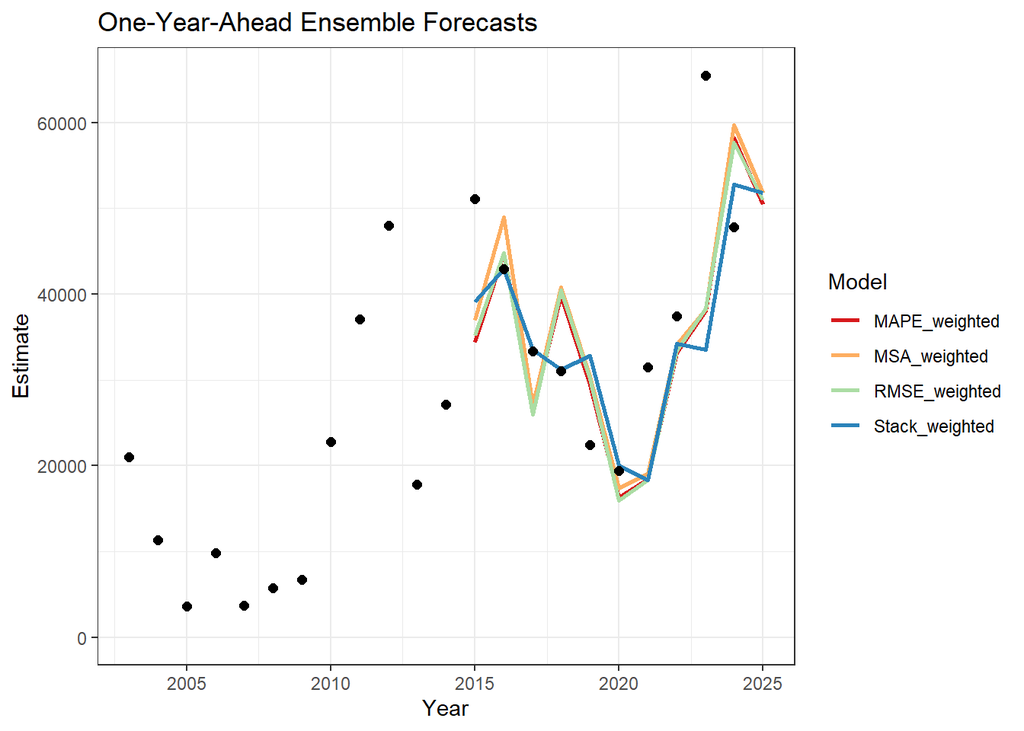

```r
#==============
#plot ensemble forecasts
#==============
ggplot(data=ensemble_results$ensembles,aes(x=Year,y=Estimate,color=Model))+
  labs(title="One-Year-Ahead Ensemble Forecasts")+
  geom_line(size=1)+
  scale_color_brewer(palette="Spectral")+
  geom_point(data=dat,mapping=aes(x=Year,y=runsize_obs),size=2,color="black")+
  ylim(0,NA)+
  theme_bw()
```

# Best Model

Identify the best model and plot and summarize its results

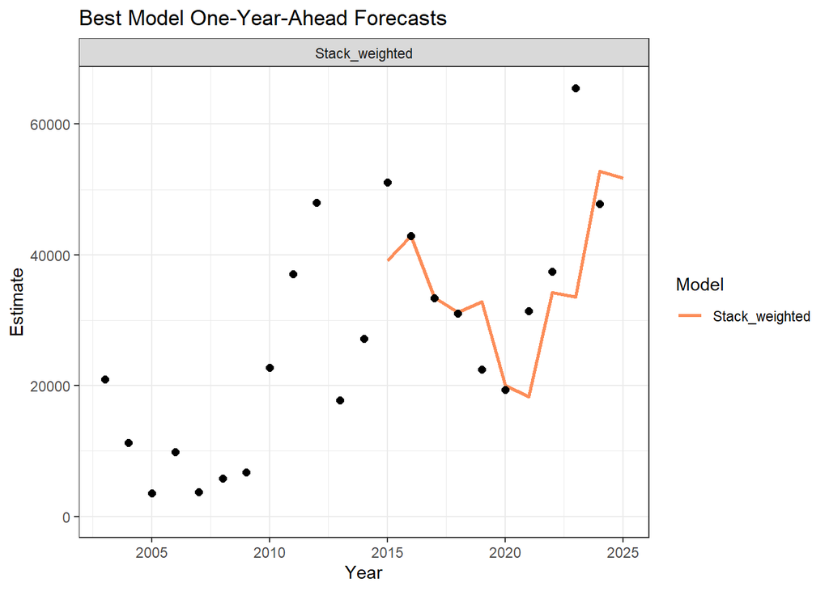

```r
best_model <- get_best_model(
  forecasts = forecasts
  ,ensembles = ensemble_results$ensembles
  ,stack_metric = stack_metric
  ,forecast_skill = ensemble_results$forecast_skill
)

write.csv(best_model,"sockeye_preseason_fcst_performance.csv")

#==============
#plot Best Model
#==============
ggplot(data=best_model,aes(x=Year,y=Estimate,color=Model))+
  #geom_ribbon(aes(ymin=L95,ymax=U95,,fill=Model),color=NA,alpha=0.4)+
  facet_wrap(~Model,ncol=1)+
  labs(title="Best Model One-Year-Ahead Forecasts")+
  geom_line(size=1)+
  scale_color_brewer(palette="Spectral")+
  geom_point(data=dat,mapping=aes(x=Year,y=runsize_obs),size=2,color="black")+
  ylim(0,NA)+
  theme_bw()
```

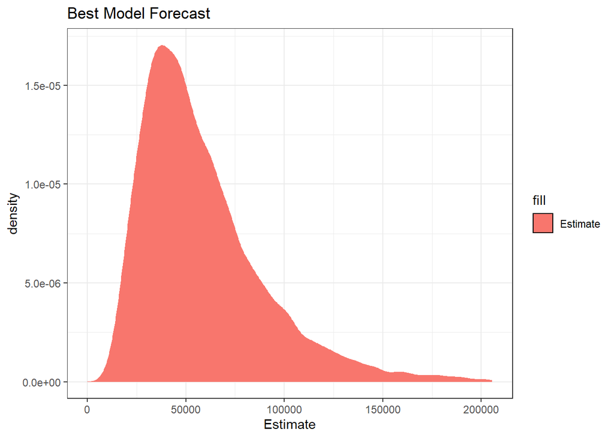

```r
best_mu<-log(best_model%>%filter(Year==max(Year))%>%dplyr::select(Estimate))%>%unlist()
best_sd<-best_model%>%filter(Year==max(Year))%>%dplyr::select(sd)%>%unlist()
best_draws=data.frame(Estimate=rlnorm(25000,mean=best_mu,sd=best_sd[1]))

sockeye_forecast <- write.csv(best_draws,"sockeyeforecast.csv")

#=========================
#Best model final Year pdf
#=========================
ggplot(data=best_draws,aes(x=Estimate,color=NA),alpha=0.4)+
  geom_density(aes(fill="Estimate"))+
  xlim(0,quantile(best_draws$Estimate,0.995))+
  labs(title="Best Model Forecast")+
  scale_color_brewer(palette="Spectral")+
  ylim(0,NA)+
  theme_bw()
```

```r
#===========================
#Best Model final Year table
#===========================
best_model%>%
  group_by(Model)%>%
  filter(Year==max(Year,na.rm=T))%>%
  dplyr::select(Model,Year,Estimate,L95,U95)%>%
  kbl(caption = "Table 5. Best model forecasts one Year ahead of final Year of data.",digits =0)%>%
  kable_classic(full_width = F, html_font = "Cambria")
```

Table 5. Best model forecasts one Year ahead of final Year of data.

| Model | Year | Estimate | L95 | U95 |
| --- | --- | --- | --- | --- |
| Stack_weighted | 2025 | 51781 | 18873 | 146626 |